# Origination Data Analysis

## Business Problem

Lenders approve loans largely on a borrower's credit score at application. That single number hides the **direction** the borrower's credit is moving: two applicants with a 700 score can carry very different risk if one is stable and the other is sliding.

This analysis of **135,000 loans (Jan-2022 to Dec-2024, ~3,750 per month)** asks:

1. Is origination volume stable?
2. What share of new borrowers already show credit deterioration at origination?
3. Do they default more, and by enough to justify changes to underwriting or pricing?

## Approach

- Grouped borrowers by pre-origination credit behaviour:
  - **Stable**: consistent credit profile
  - **Gradual Decline**: steady weakening over several months
  - **Sudden Shock**: sharp recent drop (e.g. a missed payment or a utilisation spike)
  - **Credit Seeking**: high number of recent credit enquiries
- Tracked the monthly mix of these patterns and compared their **12-month default rates**.

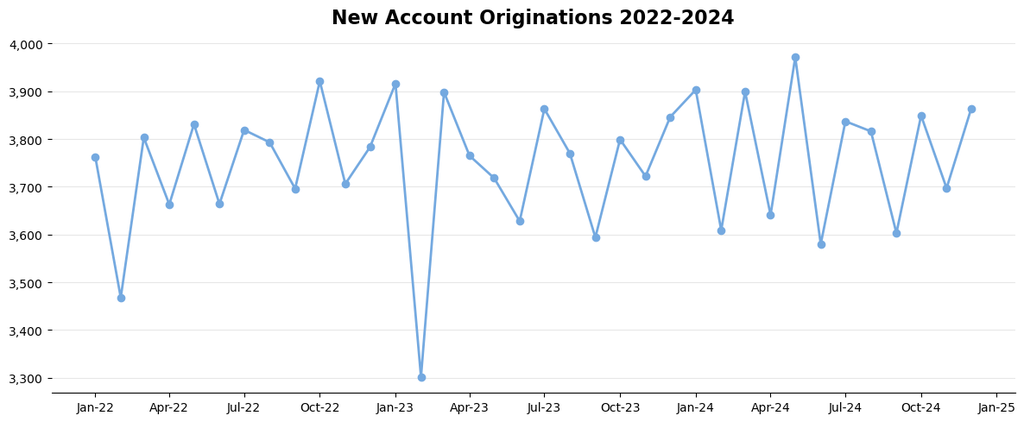

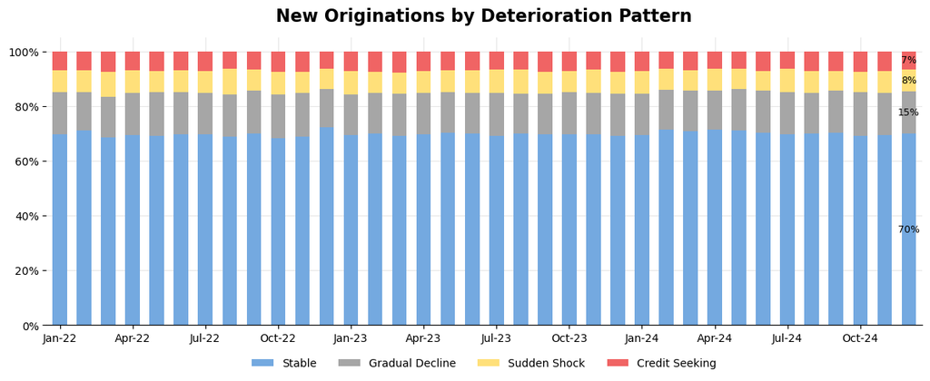

- **70%** of new originations come from consumers with stable credit score.
- **~23%** of new loans show early deterioration signals, and these default at nearly 2 times the rate of stable borrowers (11.7% vs 6.5%).

## Business Recommendations

- Add **credit trend features** (score change and utilisation change over 6–12 months) to the underwriting model, not just point-in-time scores.
- Apply **risk-based pricing or lower limits** to Gradual Decline and Sudden Shock applicants.
- Set up **early-warning monitoring** after booking, so the collections team can reach at-risk borrowers early.
- Reconsider policies that penalise credit enquiries alone, which may be turning away good customers